# PML_Course Project

Erwin E. Torres

November 25, 2018

Background

Using devices such as Jawbone Up, Nike FuelBand, and Fitbit it is now possible to collect a large amount of data about personal activity relatively inexpensively. These type of devices are part of the quantified self movement - a group of enthusiasts who take measurements about themselves regularly to improve their health, to find patterns in their behavior, or because they are tech geeks. One thing that people regularly do is quantify how much of a particular activity they do, but they rarely quantify how well they do it. In this project, your goal will be to use data from accelerometers on the belt, forearm, arm, and dumbell of 6 participants. They were asked to perform barbell lifts correctly and incorrectly in 5 different ways. More information is available from the website here: http://web.archive.org/web/20161224072740/http:/groupware.les.inf.puc-rio.br/har (see the section on the Weight Lifting Exercise Dataset).

Data

The training data for this project are available here:

https://d396qusza40orc.cloudfront.net/predmachlearn/pml-training.csv

The test data are available here:

https://d396qusza40orc.cloudfront.net/predmachlearn/pml-testing.csv

Results and Discussions

The goal of your project is to predict the manner in which they did the exercise. This is the “classe” variable in the training set. You may use any of the other variables to predict with. You should create a report describing how you built your model, how you used cross validation, what you think the expected out of sample error is, and why you made the choices you did. You will also use your prediction model to predict 20 different test cases.

1. Load necessary libraries

```r
getwd()
```

```
## [1] "C:/Users/Acer/Documents/DATA SCIENCE_DOST and COURSERA/Practical Machine Learning"
```

```r
setwd("C:/Users/Acer/Documents/DATA SCIENCE_DOST and COURSERA/Practical Machine Learning")
library(caret)
library(rattle)
library(rpart)
library(RColorBrewer)
library(randomForest)
library(gbm)
```

Load needed data.

```r
TrainingData <- read.csv("pml-training.csv")
TestingData <- read.csv("pml-testing.csv")
str(TrainingData)
```

```
## 'data.frame':    19622 obs. of  160 variables:
##  $ X                       : int  1 2 3 4 5 6 7 8 9 10 ...
##  $ user_name               : Factor w/ 6 levels "adelmo","carlitos",..: 2 2 2 2 2 2 2 2 2 2 ...
##  $ raw_timestamp_part_1    : int  1323084231 1323084231 1323084231 1323084232 1323084232 1323084232 1323084232 1323084232 1323084232 1323084232 ...
##  $ raw_timestamp_part_2    : int  788290 808298 820366 120339 196328 304277 368296 440390 484323 484434 ...
##  $ cvtd_timestamp          : Factor w/ 20 levels "02/12/2011 13:32",..: 9 9 9 9 9 9 9 9 9 9 ...
##  $ new_window              : Factor w/ 2 levels "no","yes": 1 1 1 1 1 1 1 1 1 1 ...
##  $ num_window              : int  11 11 11 12 12 12 12 12 12 12 ...
##  $ roll_belt               : num  1.41 1.41 1.42 1.48 1.48 1.45 1.42 1.42 1.43 1.45 ...
##  $ pitch_belt              : num  8.07 8.07 8.07 8.05 8.07 8.06 8.09 8.13 8.16 8.17 ...
##  $ yaw_belt                : num  -94.4 -94.4 -94.4 -94.4 -94.4 -94.4 -94.4 -94.4 -94.4 -94.4 ...
##  $ total_accel_belt        : int  3 3 3 3 3 3 3 3 3 3 ...
##  $ kurtosis_roll_belt      : Factor w/ 397 levels "","-0.016850",..: 1 1 1 1 1 1 1 1 1 1 ...
##  $ kurtosis_picth_belt     : Factor w/ 317 levels "","-0.021887",..: 1 1 1 1 1 1 1 1 1 1 ...
##  $ kurtosis_yaw_belt       : Factor w/ 2 levels "","#DIV/0!": 1 1 1 1 1 1 1 1 1 1 ...
```

[output cut: 86 more lines]

```r
str(TestingData)
```

```
## 'data.frame':    20 obs. of  160 variables:
##  $ X                       : int  1 2 3 4 5 6 7 8 9 10 ...
##  $ user_name               : Factor w/ 6 levels "adelmo","carlitos",..: 6 5 5 1 4 5 5 5 2 3 ...
##  $ raw_timestamp_part_1    : int  1323095002 1322673067 1322673075 1322832789 1322489635 1322673149 1322673128 1322673076 1323084240 1322837822 ...
##  $ raw_timestamp_part_2    : int  868349 778725 342967 560311 814776 510661 766645 54671 916313 384285 ...
##  $ cvtd_timestamp          : Factor w/ 11 levels "02/12/2011 13:33",..: 5 10 10 1 6 11 11 10 3 2 ...
##  $ new_window              : Factor w/ 1 level "no": 1 1 1 1 1 1 1 1 1 1 ...
##  $ num_window              : int  74 431 439 194 235 504 485 440 323 664 ...
##  $ roll_belt               : num  123 1.02 0.87 125 1.35 -5.92 1.2 0.43 0.93 114 ...
##  $ pitch_belt              : num  27 4.87 1.82 -41.6 3.33 1.59 4.44 4.15 6.72 22.4 ...
##  $ yaw_belt                : num  -4.75 -88.9 -88.5 162 -88.6 -87.7 -87.3 -88.5 -93.7 -13.1 ...
##  $ total_accel_belt        : int  20 4 5 17 3 4 4 4 4 18 ...
##  $ kurtosis_roll_belt      : logi  NA NA NA NA NA NA ...
##  $ kurtosis_picth_belt     : logi  NA NA NA NA NA NA ...
##  $ kurtosis_yaw_belt       : logi  NA NA NA NA NA NA ...
```

[output cut: 86 more lines]

3. Perform data cleaning by removing NA, blank data, and unecessary indices

```r
indColToRemove <- which(colSums(is.na(TrainingData) |TrainingData=="")>0.8*dim(TrainingData)[1])
Clean_TrainingData <- TrainingData[,-indColToRemove]
Clean_TrainingData <- Clean_TrainingData[,-c(1:7)] # Removing unecessary variables
dim(Clean_TrainingData)
```

```
## [1] 19622    53
```

```r
indColToRemove <- which(colSums(is.na(TestingData) |TestingData=="")>0.8*dim(TestingData)[1])
Clean_TestingData <- TestingData[,-indColToRemove]
Clean_TestingData <- Clean_TestingData[,-c(1:7)] # Removing unecessary variables
dim(Clean_TestingData)
```

```
## [1] 20 53
```

4.Create a partition of the traning data set (TrainDataClean)

```r
set.seed(12345)
inTrain <- createDataPartition(Clean_TrainingData$classe, p=0.75, list=FALSE)
Set_Training75 <- Clean_TrainingData[inTrain,] # Training data set, 75%
Set_Testing25 <- Clean_TrainingData[-inTrain,] # Test data set, 25%
```

5. Train with classification trees

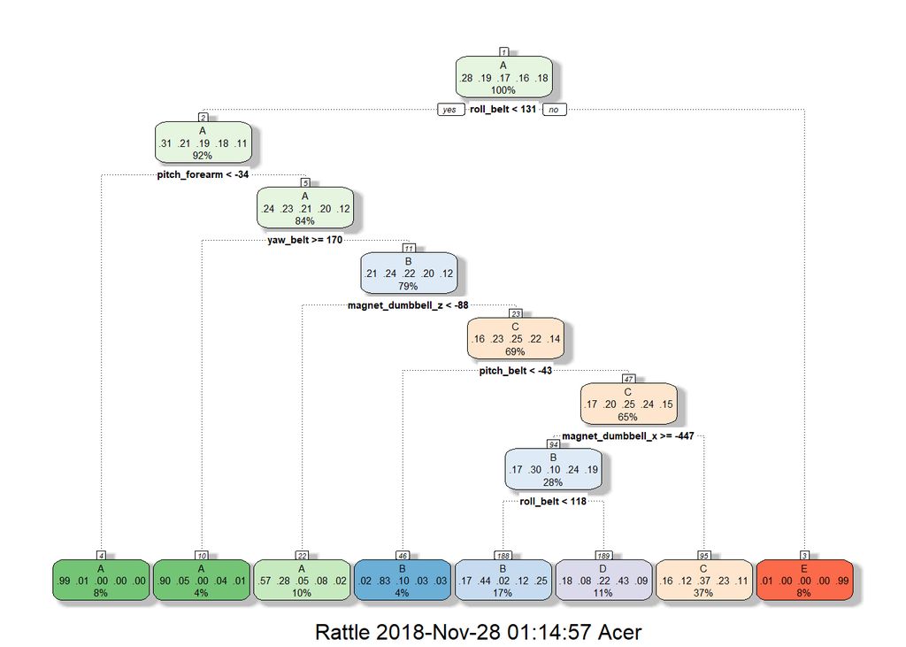

```r
Control_CT <- trainControl(method="cv", number=5)
Model_CT <- train(classe~., data=Set_Training75, method="rpart", trControl=Control_CT)
fancyRpartPlot(Model_CT$finalModel) #print(Model_CT)
```

6. Predict using classification trees using 25% test data.

```r
Pred_Training_CT <- predict(Model_CT,newdata=Set_Testing25)
```

7. Display confusion matrix and model accuracy

```r
ConfMat_CT <- confusionMatrix(Set_Testing25$classe,Pred_Training_CT)
ConfMat_CT$table
```

```
##           Reference
## Prediction   A   B   C   D   E
##          A 870 159 273  88   5
##          B 162 530 214  43   0
##          C  29  36 674 116   0
##          D  46 136 429 193   0
##          E  16 221 224  51 389
```

```r
ConfMat_CT$overall[1]
```

```
##  Accuracy
## 0.5415987
```

The classificaiton trees can predict 54% of the classes correctly.

8. Train with random forests

```r
set.seed(12345)
Model_RF <- randomForest(classe~., data=Set_Training75, importance=TRUE)
print(Model_RF)
```

```
##
## Call:
##  randomForest(formula = classe ~ ., data = Set_Training75, importance = TRUE)
##                Type of random forest: classification
##                      Number of trees: 500
## No. of variables tried at each split: 7
##
##         OOB estimate of  error rate: 0.41%
## Confusion matrix:
##      A    B    C    D    E  class.error
## A 4184    1    0    0    0 0.0002389486
## B    9 2836    3    0    0 0.0042134831
## C    0   11 2553    3    0 0.0054538372
## D    0    0   21 2388    3 0.0099502488
## E    0    0    1    8 2697 0.0033259424
```

9. Predict using random forests using 25% test data.

```r
Pred_Training_RF <- predict(Model_RF,newdata=Set_Testing25)
```

10. Display confusion matrix and model accuracy

```r
ConfMat_RF<- confusionMatrix(Set_Testing25$classe,Pred_Training_RF)
ConfMat_RF$table
```

```
##           Reference
## Prediction    A    B    C    D    E
##          A 1395    0    0    0    0
##          B    5  939    5    0    0
##          C    0    3  851    1    0
##          D    0    0    7  797    0
##          E    0    0    1    4  896
```

```r
ConfMat_RF$overall[1] # Shows the level of accuracy of the model
```

```
##  Accuracy
## 0.9946982
```

The random forest can predict 99% of the classes correctly.

11. Train with gradient boosting method

```r
set.seed(12345)
Control_GBM <- trainControl(method = "repeatedcv", number = 5, repeats = 1)
Model_GBM  <- train(classe ~ ., data=Set_Training75, method = "gbm", trControl = Control_GBM, verbose = FALSE)
Model_GBM$finalModel
```

```
## A gradient boosted model with multinomial loss function.
## 150 iterations were performed.
## There were 52 predictors of which 41 had non-zero influence.
```

```r
print(Model_GBM)
```

```
## Stochastic Gradient Boosting
##
## 14718 samples
##    52 predictor
##     5 classes: 'A', 'B', 'C', 'D', 'E'
##
## No pre-processing
## Resampling: Cross-Validated (5 fold, repeated 1 times)
## Summary of sample sizes: 11774, 11774, 11774, 11775, 11775
## Resampling results across tuning parameters:
##
##   interaction.depth  n.trees  Accuracy   Kappa
##   1                   50      0.7564204  0.6912841
##   1                  100      0.8198803  0.7719731
##   1                  150      0.8549392  0.8164228
##   2                   50      0.8549389  0.8161407
##   2                  100      0.9075278  0.8829416
##   2                  150      0.9316484  0.9134928
##   3                   50      0.8952979  0.8674514
##   3                  100      0.9424511  0.9271878
##   3                  150      0.9618833  0.9517747
##
## Tuning parameter 'shrinkage' was held constant at a value of 0.1
##
## Tuning parameter 'n.minobsinnode' was held constant at a value of 10
## Accuracy was used to select the optimal model using the largest value.
## The final values used for the model were n.trees = 150,
##  interaction.depth = 3, shrinkage = 0.1 and n.minobsinnode = 10.
```

12. Predict using gradient boosting method using 25% test data.

```r
Pred_Training_GBM <- predict(Model_GBM,newdata=Set_Testing25)
```

13. Display confusion matrix and model accuracy

```r
ConfMat_GBM <- confusionMatrix(Set_Testing25$classe,Pred_Training_GBM)
ConfMat_GBM$table
```

```
##           Reference
## Prediction    A    B    C    D    E
##          A 1378   12    4    0    1
##          B   37  880   32    0    0
##          C    0   18  824   12    1
##          D    1    1   27  770    5
##          E    2    8   12   17  862
```

```r
ConfMat_GBM$overall[1]
```

```
##  Accuracy
## 0.9612561
```

The gradient boosting method can predict 96% of the classes correctly.

Conclusion

Among the three machine learning models, random forest can predict best at 99%. Thus, this model will be used to predict the classes of the 20 test data.

```r
Final_Pred_Test_RF<- predict(Model_RF,newdata=Clean_TestingData)
Final_Pred_Test_RF
```

```
##  1  2  3  4  5  6  7  8  9 10 11 12 13 14 15 16 17 18 19 20
##  B  A  B  A  A  E  D  B  A  A  B  C  B  A  E  E  A  B  B  B
## Levels: A B C D E
```